# IMT 573 - Lab 2 - Data Visualization

### Instructions

Before beginning this assignment, please ensure you have access to a working instance of Jupyter Notebooks with Python 3.

1. First, replace the “YOUR NAME HERE” text in the next cell with your own full name. Any collaborators must also be listed in this cell.
2. Be sure to include well-documented (e.g. commented) code cells, figures, and clearly written text explanations as necessary. Any figures should be clearly labeled and appropriately referenced within the text. Be sure that each visualization adds value to your written explanation; avoid redundancy – you do no need four different visualizations of the same pattern.
3. Collaboration on problem sets and labs is fun, useful, and encouraged. However, each student must turn in an individual write-up in their own words as well as code/work that is their own. Regardless of whether you work with others, what you turn in must be your own work; this includes code and interpretation of results. The names of all collaborators must be listed on each assignment. Do not copy-and-paste from other students’ responses or code - your code should never be on any other student's screen or machine.
4. All materials and resources that you use (with the exception of lecture slides) must be appropriately referenced within your assignment.

Name: Pratiibh Bassi Collaborators: After-class session with Professor Sophin Liu

In this lab, we will look at data on the sinking of the RMS Titanic in the North Atlantic Ocean on the early morning of April 15, 1912. The data can be loaded as part of the `seaborn` package, which is imported below. `pyplot` is also imported below in case you need added functionality. You may need to install the packages if you're getting an error when importing.

Once the package is imported, the data is available by calling `sns.load_dataset("titanic")`, (note how `sns` refers to the variable from `import`). Store the data in your variable of choice.

```python
import seaborn as sns
import matplotlib.pyplot as plt
```

```python
titanic = sns.load_dataset("titanic")
```

For this lab, we will be exploring two primary questions:

- Who were the Titanic passengers and what charactersitics did they have?
- What passenger characteristics or other factors seem to be associated with survival?

Your task will be to create visualizations to better explore each of these questions.

### Problem 1: Who were the Titanic passengers?

Let's take a look at the titanic passengers in terms of their age and recorded gender (labelled "sex" in the dataset). To examine this, create a violin plot visualization that shows a histogram of ages for each sex, broken down by whether the passenger survived. You can read more on violin plots [here](https://seaborn.pydata.org/generated/seaborn.violinplot.html). An example of what your visualization may look like can be found [here](https://drive.google.com/file/d/1aunGBuEso3zpn4QOb688WQD5Quqtzy_s/view?usp=drive_link).

For your visualization:

- change the color of the histograms from the default colors
- add gridlines across whichever axis shows age (hint: use the `set_style()` function to help with this. For more, see [here](https://seaborn.pydata.org/generated/seaborn.set_style.html).
- add axis labels and a title

```python
titanic
```

|  | survived | pclass | sex | age | sibsp | parch | fare | embarked | class | who | adult_male | deck | embark_town | alive | alone |
| --- | --- | --- | --- | --- | --- | --- | --- | --- | --- | --- | --- | --- | --- | --- | --- |
| 0 | 0 | 3 | male | 22.0 | 1 | 0 | 7.2500 | S | Third | man | True | NaN | Southampton | no | False |
| 1 | 1 | 1 | female | 38.0 | 1 | 0 | 71.2833 | C | First | woman | False | C | Cherbourg | yes | False |
| 2 | 1 | 3 | female | 26.0 | 0 | 0 | 7.9250 | S | Third | woman | False | NaN | Southampton | yes | True |
| 3 | 1 | 1 | female | 35.0 | 1 | 0 | 53.1000 | S | First | woman | False | C | Southampton | yes | False |
| 4 | 0 | 3 | male | 35.0 | 0 | 0 | 8.0500 | S | Third | man | True | NaN | Southampton | no | True |
| ... | ... | ... | ... | ... | ... | ... | ... | ... | ... | ... | ... | ... | ... | ... | ... |
| 886 | 0 | 2 | male | 27.0 | 0 | 0 | 13.0000 | S | Second | man | True | NaN | Southampton | no | True |
| 887 | 1 | 1 | female | 19.0 | 0 | 0 | 30.0000 | S | First | woman | False | B | Southampton | yes | True |
| 888 | 0 | 3 | female | NaN | 1 | 2 | 23.4500 | S | Third | woman | False | NaN | Southampton | no | False |
| 889 | 1 | 1 | male | 26.0 | 0 | 0 | 30.0000 | C | First | man | True | C | Cherbourg | yes | True |
| 890 | 0 | 3 | male | 32.0 | 0 | 0 | 7.7500 | Q | Third | man | True | NaN | Queenstown | no | True |

891 rows × 15 columns

```python
titanic.dtypes
```

```
survived          int64
pclass            int64
sex              object
age             float64
sibsp             int64
parch             int64
fare            float64
embarked         object
class          category
who              object
adult_male         bool
deck           category
embark_town      object
alive            object
alone              bool
dtype: object
```

```python
titanic.describe()
```

|  | survived | pclass | age | sibsp | parch | fare |
| --- | --- | --- | --- | --- | --- | --- |
| count | 891.000000 | 891.000000 | 714.000000 | 891.000000 | 891.000000 | 891.000000 |
| mean | 0.383838 | 2.308642 | 29.699118 | 0.523008 | 0.381594 | 32.204208 |
| std | 0.486592 | 0.836071 | 14.526497 | 1.102743 | 0.806057 | 49.693429 |
| min | 0.000000 | 1.000000 | 0.420000 | 0.000000 | 0.000000 | 0.000000 |
| 25% | 0.000000 | 2.000000 | 20.125000 | 0.000000 | 0.000000 | 7.910400 |
| 50% | 0.000000 | 3.000000 | 28.000000 | 0.000000 | 0.000000 | 14.454200 |
| 75% | 1.000000 | 3.000000 | 38.000000 | 1.000000 | 0.000000 | 31.000000 |
| max | 1.000000 | 3.000000 | 80.000000 | 8.000000 | 6.000000 | 512.329200 |

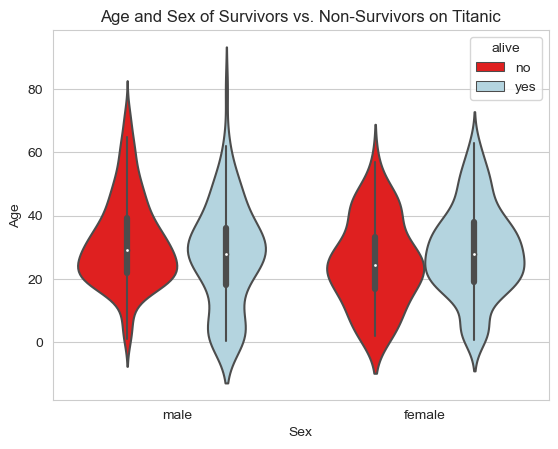

```python
sns.violinplot(data=titanic, hue = "alive", x = "sex", y = "age", showmeans=False, palette = ['red', 'lightblue'])
sns.set_style("whitegrid")
plt.xlabel("Sex")
plt.ylabel("Age")
plt.title("Age and Sex of Survivors vs. Non-Survivors on Titanic")
```

Using dark red to denote people who died, lightblue to denote people who survived

### Problem 2: A visualization of your own

Now, create a visualization of your own that shows relationships between passenger characteristics and survival. You must:

- create a visualization other than a violin visualization
- use (at least) two variables other than survival in your visualization
- appropriately label the axes and add a title

After creating your visualization, provide a paragraph describing what the visualization shows.

Have fun and be creative!

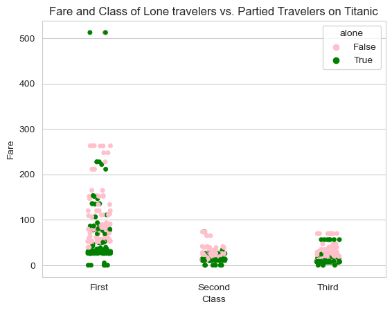

```python
sns.stripplot(data=titanic, hue = "alone", x = "class", y = "fare", palette = ['pink', 'green'])
sns.set_style("whitegrid")
plt.ylabel("Fare")
plt.xlabel("Class")
plt.title("Fare and Class of Lone travelers vs. Partied Travelers on Titanic")
```

The visualization shows the fare paid by each passenger along with what class ticket they purchased versus whether they were alone or traveled with other passengers that were aboard the Titanic. One would presume that due to the high cost of first class tickets, those traveling in the first class paid much more for their tickets vs the second and third class. This is supported by the visualization. One would also assume that due to the high cost of a first class ticket, most traveling in the first class probably were traveling alone. The visualization shows that there were quite a lot of passengers who weren't traveling alone and paid for expensive first class tickets. However, the visualization shows that only one traveler paid a fare more than 300 dollars and wasn't alone! While there were quite a number of first class passengers who traveled with others and paid an expensive fare, for the majority of passengers who had a fare of higher than $300, were lone passengers (2/3).